# Intergenerational Language Transmission

Household-level analysis — Bolivia CNPV 2024

```r
library(tidyverse)
library(sf)
library(patchwork)
library(plotly)

source("cel_helpers.R")   # loads muni_lookup, idioma_cats, etc.
```

```
cel_helpers.R loaded: compute_cel(), read_census_geo(), lookup tables, cel_colors.
```

```r
DATA_DIR <- "../bolivia-data/censo_2024/base_datos_csv_2024"

aymara_transmission_clean  <- readRDS("data/aymara_transmission_by_muni.rds")
quechua_transmission_clean <- readRDS("data/quechua_transmission_by_muni.rds")
guarani_transmission_clean <- readRDS("data/guarani_transmission_by_muni.rds")
other_transmission_clean   <- readRDS("data/other_transmission_by_muni.rds")

muni_pop_all      <- readRDS("data/muni_pop_all.rds")
other_lang_labels <- readRDS("data/other_lang_labels.rds")

cel_geo <- readRDS(file.path(DATA_DIR, "cel_geo.rds"))
```

For each child aged 0–14, we identify parents in the same dwelling (head of household and spouse, `p24_parentes` codes 1 and 2). We then ask: among children whose parent speaks Aymara (or Quechua, Guaraní, etc.) as a mother tongue, what percentage currently speak that language themselves (in any of their three `p331`/`p332`/`p333` slots)?

This is a direct measure of parental language transmission — not of cultural identity, but of whether the language is actively spoken to children at home.

```r
aymara_nat  <- aymara_transmission_clean  |>
  summarise(n = sum(n_children_with_parent), s = sum(n_children_speak_aymara))
quechua_nat <- quechua_transmission_clean |>
  summarise(n = sum(n_children_with_parent), s = sum(n_children_speak_quechua))
guarani_nat <- guarani_transmission_clean |>
  summarise(n = sum(n_children_with_parent), s = sum(n_children_speak_guarani))
other_nat   <- other_transmission_clean   |>
  summarise(n = sum(n_children_with_parent), s = sum(n_children_speak_other))

cat(sprintf("Aymara  — %s children with Aymara-speaking parent(s); %s speak Aymara (%.1f%%)\n",
    scales::comma(aymara_nat$n), scales::comma(aymara_nat$s),
    100 * aymara_nat$s / aymara_nat$n))
```

```
Aymara  — 425,655 children with Aymara-speaking parent(s); 123,894 speak Aymara (29.1%)
```

```r
cat(sprintf("Quechua — %s children with Quechua-speaking parent(s); %s speak Quechua (%.1f%%)\n",
    scales::comma(quechua_nat$n), scales::comma(quechua_nat$s),
    100 * quechua_nat$s / quechua_nat$n))
```

```
Quechua — 915,114 children with Quechua-speaking parent(s); 365,976 speak Quechua (40.0%)
```

```r
cat(sprintf("Guaraní — %s children with Guaraní-speaking parent(s); %s speak Guaraní (%.1f%%)\n",
    scales::comma(guarani_nat$n), scales::comma(guarani_nat$s),
    100 * guarani_nat$s / guarani_nat$n))
```

```
Guaraní — 36,324 children with Guaraní-speaking parent(s); 20,154 speak Guaraní (55.5%)
```

```r
cat(sprintf("Other   — %s children with other-indigenous-speaking parent(s); %s speak same language (%.1f%%)\n",
    scales::comma(other_nat$n), scales::comma(other_nat$s),
    100 * other_nat$s / other_nat$n))
```

```
Other   — 38,256 children with other-indigenous-speaking parent(s); 25,972 speak same language (67.9%)
```

National transmission rates vary markedly across language families. **Guaraní (56%) and other indigenous languages (68%) transmit at considerably higher rates than Aymara (29%) or Quechua (40%).** This reflects the geographic and demographic context: Guaraní and smaller lowland languages are concentrated in tight-knit, often rural communities where Spanish pressure is lower, whereas Aymara and Quechua speakers include large urban populations (El Alto, La Paz, Cochabamba) where language shift is most pronounced.

```r
gadm_bol    <- read_sf("data/gadm41_BOL_3.gpkg", layer = "ADM_ADM_3")
gadm_joined <- gadm_bol |>
  left_join(
    muni_lookup |> select(id_muni, muni_gadm, department) |> distinct(),
    by = c("NAME_3" = "muni_gadm", "NAME_1" = "department")
  )
```

```r
# ── Bar chart: top N municipalities by speaker count ─────────────────────────
top30_chart <- function(transmission_df, speaker_col, lang_name, fill_colour,
                        min_parents = 10, n = 30) {
  transmission_df |>
    filter(!is.na(.data[[speaker_col]])) |>
    slice_max(order_by = .data[[speaker_col]], n = n) |>
    left_join(
      muni_lookup |> select(id_muni, muni_ine, department) |> distinct(),
      by = c("muni_code" = "id_muni")
    ) |>
    mutate(
      label     = coalesce(paste0(muni_ine, " (", department, ")"),
                           paste0("(", muni_code, ")")),
      label     = fct_reorder(label, .data[[speaker_col]]),
      show_rate = if_else(n_children_with_parent >= min_parents,
                          transmission_rate, NA_real_)
    ) |>
    ggplot(aes(x = show_rate, y = label)) +
    geom_col(fill = fill_colour, alpha = 0.8, na.rm = TRUE) +
    geom_text(
      aes(label = if_else(!is.na(show_rate),
                          scales::percent(show_rate, accuracy = 1), "—"),
          x     = if_else(!is.na(show_rate), show_rate + 0.01, 0.01)),
      hjust = 0, size = 3.2, color = "grey30"
    ) +
    scale_x_continuous(
      labels = scales::percent_format(),
      expand = expansion(mult = c(0, 0.18))
    ) +
    labs(
      title    = paste0(lang_name, " transmission — top 30 municipalities by speaker count"),
      subtitle = paste0("Bolivia CNPV 2024  |  bars suppressed where <",
                        min_parents, " speaking parents"),
      x = "Transmission rate", y = NULL
    ) +
    theme_minimal(base_size = 11) +
    theme(
      plot.title         = element_text(face = "bold", margin = margin(b = 3)),
      plot.subtitle      = element_text(color = "grey40", size = rel(0.82),
                                        margin = margin(b = 8)),
      panel.grid.major.y = element_blank()
    )
}

# ── Interactive bubble chart: prevalence vs. transmission ────────────────────
bubble_chart_ly <- function(transmission_df, speaker_col, parent_col, child_speak_col,
                             lang_name, fill_colour, muni_pop, min_parents = 10, n = 50) {

  plot_data <- transmission_df |>
    filter(!is.na(.data[[speaker_col]]),
           n_children_with_parent >= min_parents) |>
    slice_max(order_by = .data[[speaker_col]], n = n) |>
    left_join(muni_pop, by = "muni_code") |>
    left_join(
      muni_lookup |> select(id_muni, muni_ine, department) |> distinct(),
      by = c("muni_code" = "id_muni")
    ) |>
    mutate(
      speaker_share = .data[[speaker_col]] / n_total,
      muni_label    = coalesce(muni_ine, muni_code),
      tooltip = paste0(
        "<b>", muni_label, "</b>   ", department, "<br>",
        "<br>",
        "Total population: ", scales::comma(n_total), "<br>",
        "Speakers: ", scales::comma(.data[[speaker_col]]), "<br>",
        "Speaking parents: ", scales::comma(.data[[parent_col]]), "<br>",
        "Children with parent: ", scales::comma(n_children_with_parent), "<br>",
        "Children speaking: ", scales::comma(.data[[child_speak_col]]), "<br>",
        "Transmission: ", scales::percent(transmission_rate, accuracy = 1)
      )
    )

  plot_data <- plot_data |> mutate(.size = .data[[speaker_col]])

  plot_ly(
    data      = plot_data,
    x         = ~speaker_share,
    y         = ~transmission_rate,
    size      = ~.size,
    sizes     = c(36, 53^2),
    text      = ~tooltip,
    hoverinfo = "text",
    type      = "scatter",
    mode      = "markers",
    marker    = list(
      color    = fill_colour,
      opacity  = 0.75,
      sizemode = "area",
      line     = list(color = "white", width = 1.5)
    )
  ) |>
    layout(
      title = list(
        text = paste0(lang_name, " \u2014 prevalence vs. transmission rate<br>",
                      "<sup>Bolivia CNPV 2024 \u2502 top ", n,
                      " municipalities by speaker count</sup>"),
        font = list(size = 14)
      ),
      xaxis = list(
        title      = paste0("Share of municipal population (", lang_name, " mother tongue)"),
        tickformat = ".0%",
        zeroline   = FALSE
      ),
      yaxis = list(
        title      = "Transmission rate",
        tickformat = ".0%",
        range      = c(0, 1),
        zeroline   = FALSE,
        scaleanchor = "x",
        scaleratio = 1
        ),
      hoverlabel = list(
        bgcolor     = "white",
        bordercolor = "#cccccc",
        font        = list(color = "#333333", size = 12)
      ),
      showlegend = FALSE
    )
}
```

## Choropleths: speakers and transmission rate

### Aymara

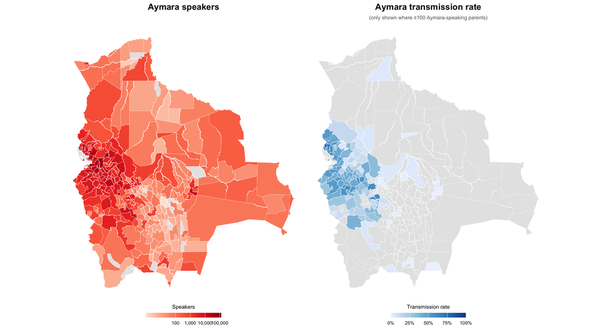

```r
aymara_choropleth <- gadm_joined |>
  left_join(aymara_transmission_clean, by = c("id_muni" = "muni_code")) |>
  mutate(
    transmission_mapped = if_else(
      !is.na(n_parents_aymara) & n_parents_aymara >= 100,
      transmission_rate, NA_real_
    )
  )

p_map_speakers <- ggplot(aymara_choropleth) +
  geom_sf(aes(fill = n_speakers_aymara), color = "white", linewidth = 0.1) +
  scale_fill_distiller(
    palette = "Reds", direction = 1, na.value = "grey90",
    labels = scales::comma, name = "Speakers",
    trans = "log10", breaks = c(100, 1000, 10000, 100000),
    guide = guide_colorbar(barwidth = 8, barheight = 0.5, title.position = "top")
  ) +
  labs(title = "Aymara speakers") +
  theme_void(base_size = 11) +
  theme(
    plot.title      = element_text(face = "bold", hjust = 0.5, margin = margin(b = 6)),
    legend.position = "bottom",
    legend.title    = element_text(size = rel(0.75), hjust = 0.5),
    legend.text     = element_text(size = rel(0.65))
  )

p_map_transmission <- ggplot(aymara_choropleth) +
  geom_sf(aes(fill = transmission_mapped), color = "white", linewidth = 0.1) +
  scale_fill_distiller(
    palette = "Blues", direction = 1, na.value = "grey90",
    labels = scales::percent_format(accuracy = 1),
    name = "Transmission rate", limits = c(0, 1),
    guide = guide_colorbar(barwidth = 8, barheight = 0.5, title.position = "top")
  ) +
  labs(title    = "Aymara transmission rate",
       subtitle = "(only shown where ≥100 Aymara-speaking parents)") +
  theme_void(base_size = 11) +
  theme(
    plot.title      = element_text(face = "bold", hjust = 0.5, margin = margin(b = 2)),
    plot.subtitle   = element_text(color = "grey40", size = rel(0.72), hjust = 0.5,
                                   margin = margin(b = 6)),
    legend.position = "bottom",
    legend.title    = element_text(size = rel(0.75), hjust = 0.5),
    legend.text     = element_text(size = rel(0.65))
  )

p_map_speakers | p_map_transmission
```

Aymara speakers are concentrated in the altiplano (La Paz and Oruro departments), with a secondary presence in Cochabamba and Santa Cruz. Rural altiplano municipalities around Lake Titicaca show the highest transmission (40–65%). El Alto and La Paz city show much lower transmission (12% and 7% respectively) despite having the largest absolute speaker populations, consistent with urban language shift.

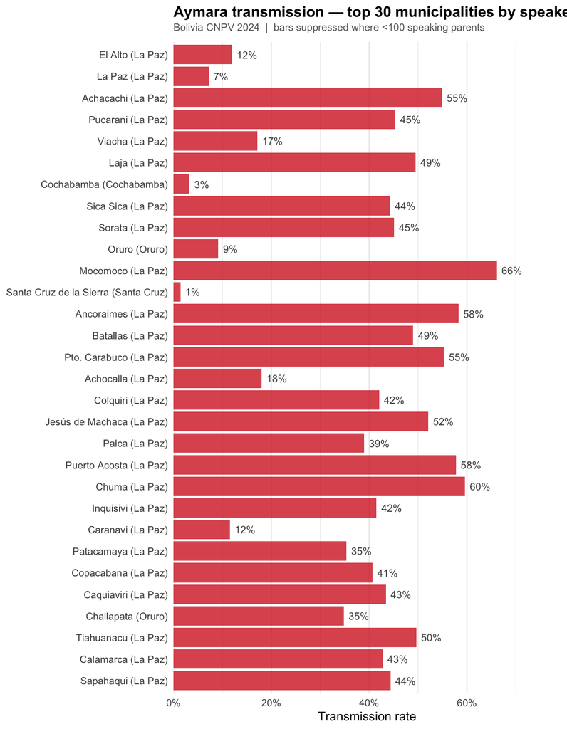

```r
top30_chart(aymara_transmission_clean, "n_speakers_aymara", "Aymara", "#d62728",
            min_parents = 100)
```

```r
bubble_chart_ly(aymara_transmission_clean,
                speaker_col     = "n_speakers_aymara",
                parent_col      = "n_parents_aymara",
                child_speak_col = "n_children_speak_aymara",
                lang_name       = "Aymara",
                fill_colour     = "#d62728",
                muni_pop        = muni_pop_all,
                min_parents     = 100)
```

[interactive chart not shown]

### Quechua

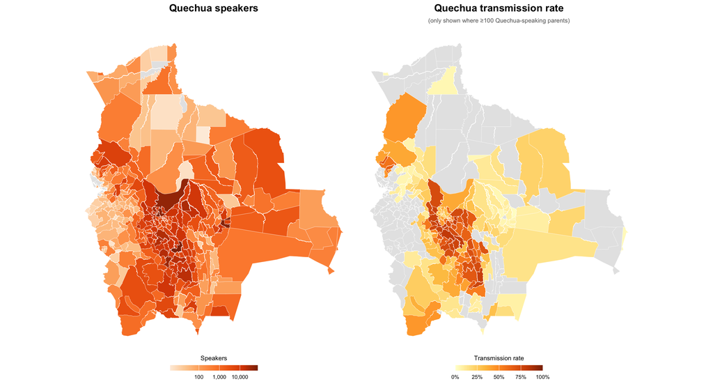

```r
quechua_choropleth <- gadm_joined |>
  left_join(quechua_transmission_clean, by = c("id_muni" = "muni_code")) |>
  mutate(
    transmission_mapped = if_else(
      !is.na(n_parents_quechua) & n_parents_quechua >= 100,
      transmission_rate, NA_real_
    )
  )

p_q_speakers <- ggplot(quechua_choropleth) +
  geom_sf(aes(fill = n_speakers_quechua), color = "white", linewidth = 0.1) +
  scale_fill_distiller(
    palette = "Oranges", direction = 1, na.value = "grey90",
    labels = scales::comma, name = "Speakers",
    trans = "log10", breaks = c(100, 1000, 10000, 100000),
    guide = guide_colorbar(barwidth = 8, barheight = 0.5, title.position = "top")
  ) +
  labs(title = "Quechua speakers") +
  theme_void(base_size = 11) +
  theme(
    plot.title      = element_text(face = "bold", hjust = 0.5, margin = margin(b = 6)),
    legend.position = "bottom",
    legend.title    = element_text(size = rel(0.75), hjust = 0.5),
    legend.text     = element_text(size = rel(0.65))
  )

p_q_transmission <- ggplot(quechua_choropleth) +
  geom_sf(aes(fill = transmission_mapped), color = "white", linewidth = 0.1) +
  scale_fill_distiller(
    palette = "YlOrBr", direction = 1, na.value = "grey90",
    labels = scales::percent_format(accuracy = 1),
    name = "Transmission rate", limits = c(0, 1),
    guide = guide_colorbar(barwidth = 8, barheight = 0.5, title.position = "top")
  ) +
  labs(title    = "Quechua transmission rate",
       subtitle = "(only shown where ≥100 Quechua-speaking parents)") +
  theme_void(base_size = 11) +
  theme(
    plot.title      = element_text(face = "bold", hjust = 0.5, margin = margin(b = 2)),
    plot.subtitle   = element_text(color = "grey40", size = rel(0.72), hjust = 0.5,
                                   margin = margin(b = 6)),
    legend.position = "bottom",
    legend.title    = element_text(size = rel(0.75), hjust = 0.5),
    legend.text     = element_text(size = rel(0.65))
  )

p_q_speakers | p_q_transmission
```

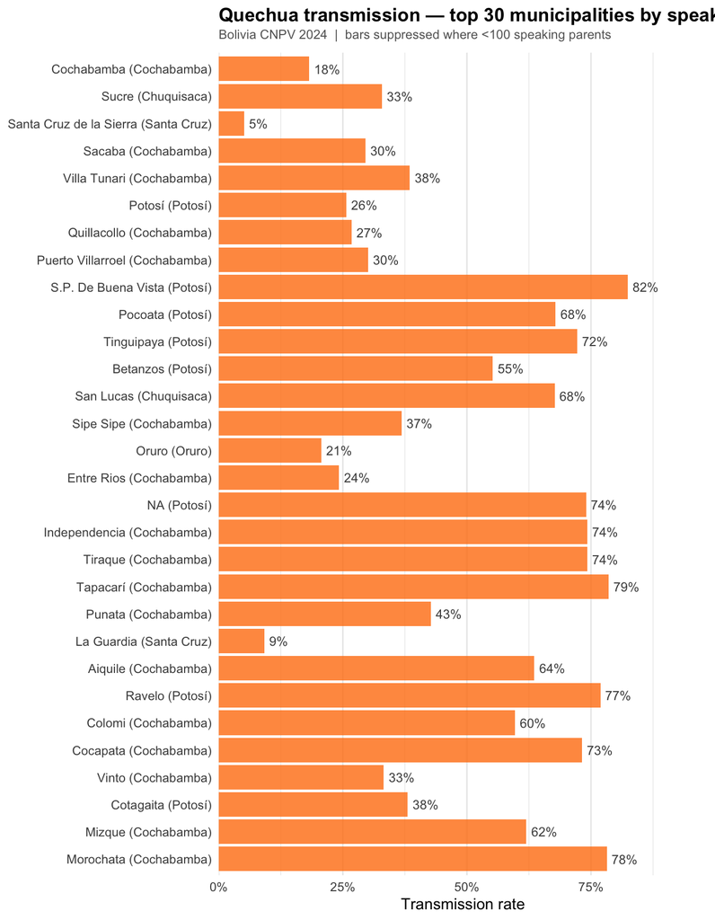

```r
top30_chart(quechua_transmission_clean, "n_speakers_quechua", "Quechua", "#ff7f0e",
            min_parents = 100)
```

```r
bubble_chart_ly(quechua_transmission_clean,
                speaker_col     = "n_speakers_quechua",
                parent_col      = "n_parents_quechua",
                child_speak_col = "n_children_speak_quechua",
                lang_name       = "Quechua",
                fill_colour     = "#ff7f0e",
                muni_pop        = muni_pop_all,
                min_parents     = 100)
```

[interactive chart not shown]

### Guaraní

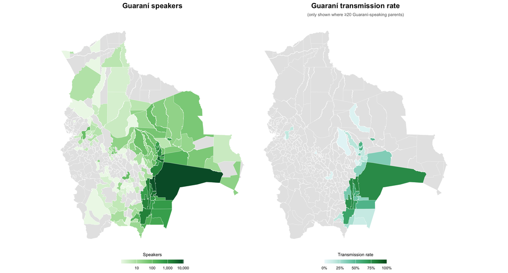

```r
guarani_choropleth <- gadm_joined |>
  left_join(guarani_transmission_clean, by = c("id_muni" = "muni_code")) |>
  mutate(
    transmission_mapped = if_else(
      !is.na(n_parents_guarani) & n_parents_guarani >= 20,
      transmission_rate, NA_real_
    )
  )

p_g_speakers <- ggplot(guarani_choropleth) +
  geom_sf(aes(fill = n_speakers_guarani), color = "white", linewidth = 0.1) +
  scale_fill_distiller(
    palette = "Greens", direction = 1, na.value = "grey90",
    labels = scales::comma, name = "Speakers",
    trans = "log10", breaks = c(10, 100, 1000, 10000),
    guide = guide_colorbar(barwidth = 8, barheight = 0.5, title.position = "top")
  ) +
  labs(title = "Guaraní speakers") +
  theme_void(base_size = 11) +
  theme(
    plot.title      = element_text(face = "bold", hjust = 0.5, margin = margin(b = 6)),
    legend.position = "bottom",
    legend.title    = element_text(size = rel(0.75), hjust = 0.5),
    legend.text     = element_text(size = rel(0.65))
  )

p_g_transmission <- ggplot(guarani_choropleth) +
  geom_sf(aes(fill = transmission_mapped), color = "white", linewidth = 0.1) +
  scale_fill_distiller(
    palette = "BuGn", direction = 1, na.value = "grey90",
    labels = scales::percent_format(accuracy = 1),
    name = "Transmission rate", limits = c(0, 1),
    guide = guide_colorbar(barwidth = 8, barheight = 0.5, title.position = "top")
  ) +
  labs(title    = "Guaraní transmission rate",
       subtitle = "(only shown where ≥20 Guaraní-speaking parents)") +
  theme_void(base_size = 11) +
  theme(
    plot.title      = element_text(face = "bold", hjust = 0.5, margin = margin(b = 2)),
    plot.subtitle   = element_text(color = "grey40", size = rel(0.72), hjust = 0.5,
                                   margin = margin(b = 6)),
    legend.position = "bottom",
    legend.title    = element_text(size = rel(0.75), hjust = 0.5),
    legend.text     = element_text(size = rel(0.65))
  )

p_g_speakers | p_g_transmission
```

Guaraní is concentrated in the Chaco lowlands of Tarija, Chuquisaca, and Santa Cruz. The transmission map is shown at a lower threshold (≥20 Guaraní-speaking parents) given smaller community sizes. High-transmission municipalities cluster in the Chaco Boreal where Guaraní-speaking communities are most intact.

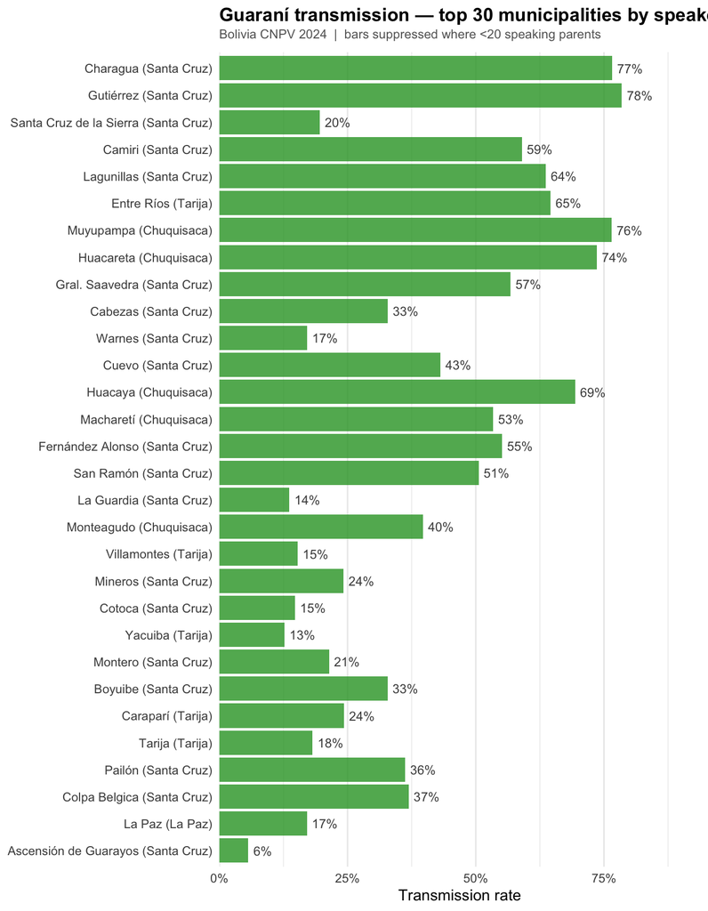

```r
top30_chart(guarani_transmission_clean, "n_speakers_guarani", "Guaraní", "#2ca02c",
            min_parents = 20)
```

```r
bubble_chart_ly(guarani_transmission_clean,
                speaker_col     = "n_speakers_guarani",
                parent_col      = "n_parents_guarani",
                child_speak_col = "n_children_speak_guarani",
                lang_name       = "Guaraní",
                fill_colour     = "#2ca02c",
                muni_pop        = muni_pop_all,
                min_parents     = 20)
```

[interactive chart not shown]

### Other indigenous languages

The “other” category aggregates all indigenous languages other than Aymara, Quechua, and Guaraní (codes 1–37 in the census, excluding 2, 12, 27). Transmission is evaluated language-specifically — a child is counted as “speaking” only if they speak the same language as their parent, not just any indigenous language. This group includes Tsimane´, Chiquitano (Bésiro), Moxeño, Mosetén, Cavineño, Uru-Chipaya, Tacana, and dozens of smaller lowland languages.

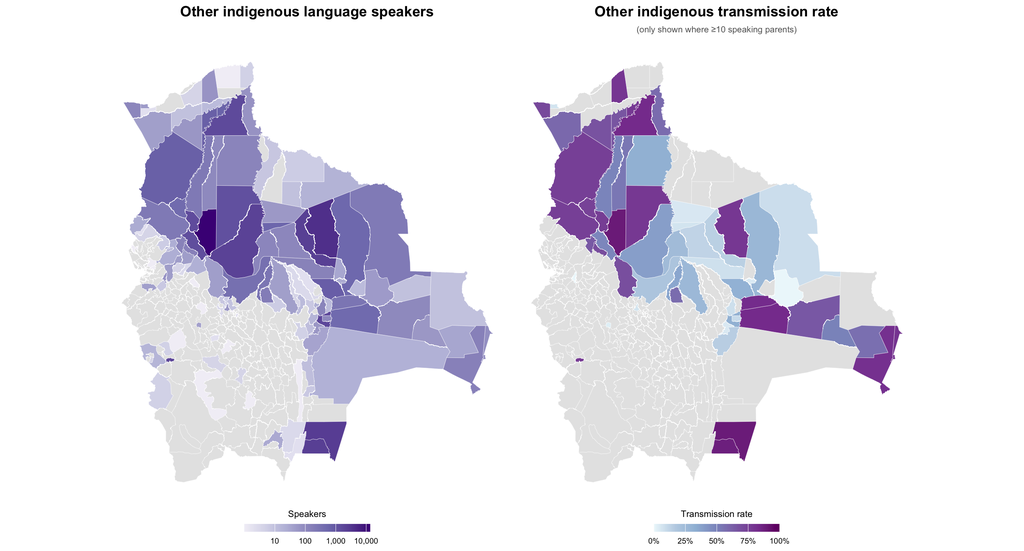

```r
other_choropleth <- gadm_joined |>
  left_join(other_transmission_clean, by = c("id_muni" = "muni_code")) |>
  mutate(
    transmission_mapped = if_else(
      !is.na(n_parents_other) & n_parents_other >= 10,
      transmission_rate, NA_real_
    )
  )

p_o_speakers <- ggplot(other_choropleth) +
  geom_sf(aes(fill = n_speakers_other), color = "white", linewidth = 0.1) +
  scale_fill_distiller(
    palette = "Purples", direction = 1, na.value = "grey90",
    labels = scales::comma, name = "Speakers",
    trans = "log10", breaks = c(10, 100, 1000, 10000),
    guide = guide_colorbar(barwidth = 8, barheight = 0.5, title.position = "top")
  ) +
  labs(title = "Other indigenous language speakers") +
  theme_void(base_size = 11) +
  theme(
    plot.title      = element_text(face = "bold", hjust = 0.5, margin = margin(b = 6)),
    legend.position = "bottom",
    legend.title    = element_text(size = rel(0.75), hjust = 0.5),
    legend.text     = element_text(size = rel(0.65))
  )

p_o_transmission <- ggplot(other_choropleth) +
  geom_sf(aes(fill = transmission_mapped), color = "white", linewidth = 0.1) +
  scale_fill_distiller(
    palette = "BuPu", direction = 1, na.value = "grey90",
    labels = scales::percent_format(accuracy = 1),
    name = "Transmission rate", limits = c(0, 1),
    guide = guide_colorbar(barwidth = 8, barheight = 0.5, title.position = "top")
  ) +
  labs(title    = "Other indigenous transmission rate",
       subtitle = "(only shown where ≥10 speaking parents)") +
  theme_void(base_size = 11) +
  theme(
    plot.title      = element_text(face = "bold", hjust = 0.5, margin = margin(b = 2)),
    plot.subtitle   = element_text(color = "grey40", size = rel(0.72), hjust = 0.5,
                                   margin = margin(b = 6)),
    legend.position = "bottom",
    legend.title    = element_text(size = rel(0.75), hjust = 0.5),
    legend.text     = element_text(size = rel(0.65))
  )

p_o_speakers | p_o_transmission
```

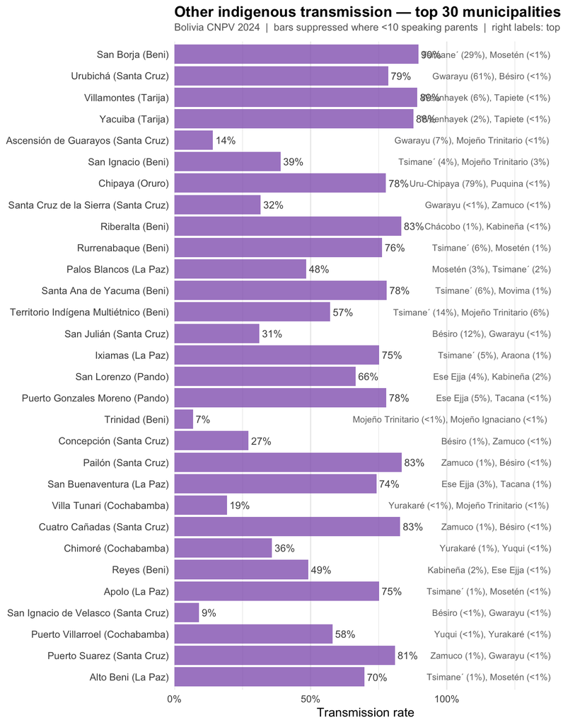

```r
local({
  fill_colour <- "#9467bd"
  speaker_col <- "n_speakers_other"
  min_parents <- 10
  n           <- 30

  plot_data <- other_transmission_clean |>
    filter(!is.na(.data[[speaker_col]])) |>
    slice_max(order_by = .data[[speaker_col]], n = n) |>
    left_join(
      muni_lookup |> select(id_muni, muni_ine, department) |> distinct(),
      by = c("muni_code" = "id_muni")
    ) |>
    left_join(other_lang_labels, by = "muni_code") |>
    mutate(
      label     = coalesce(paste0(muni_ine, " (", department, ")"),
                           paste0("(", muni_code, ")")),
      label     = fct_reorder(label, .data[[speaker_col]]),
      show_rate = if_else(n_children_with_parent >= min_parents,
                          transmission_rate, NA_real_)
    )

  ggplot(plot_data, aes(x = show_rate, y = label)) +
    geom_col(fill = fill_colour, alpha = 0.8, na.rm = TRUE) +
    geom_text(
      aes(label = if_else(!is.na(show_rate),
                          scales::percent(show_rate, accuracy = 1), "—"),
          x     = if_else(!is.na(show_rate), show_rate + 0.01, 0.01)),
      hjust = 0, size = 3.2, color = "grey30"
    ) +
    geom_text(
      aes(x = Inf, label = right_label),
      hjust = 1.05, size = 2.8, color = "grey45", na.rm = TRUE
    ) +
    scale_x_continuous(
      labels = scales::percent_format(),
      expand = expansion(mult = c(0, 0.55))
    ) +
    labs(
      title    = "Other indigenous transmission — top 30 municipalities by speaker count",
      subtitle = paste0(
        "Bolivia CNPV 2024  |  bars suppressed where <", min_parents,
        " speaking parents  |  right labels: top 2 other-language mother tongues (% of pop.)"
      ),
      x = "Transmission rate", y = NULL
    ) +
    theme_minimal(base_size = 11) +
    theme(
      plot.title         = element_text(face = "bold", margin = margin(b = 3)),
      plot.subtitle      = element_text(color = "grey40", size = rel(0.82),
                                        margin = margin(b = 8)),
      panel.grid.major.y = element_blank()
    )
})
```

```r
bubble_chart_ly(other_transmission_clean,
                speaker_col     = "n_speakers_other",
                parent_col      = "n_parents_other",
                child_speak_col = "n_children_speak_other",
                lang_name       = "Other indigenous",
                fill_colour     = "#9467bd",
                muni_pop        = muni_pop_all,
                min_parents     = 10)
```

[interactive chart not shown]

## Combined: prevalence vs. transmission rate

```r
lang_colors <- c(
  "Aymara"           = "#d62728",
  "Quechua"          = "#ff7f0e",
  "Guaraní"          = "#2ca02c",
  "Other indigenous" = "#9467bd"
)

combined_data <- bind_rows(
  aymara_transmission_clean |>
    filter(!is.na(n_speakers_aymara), n_children_with_parent >= 100) |>
    slice_max(n_speakers_aymara, n = 50) |>
    transmute(muni_code, language = "Aymara",
              n_speakers = n_speakers_aymara, n_parents = n_parents_aymara,
              n_children_with_parent,
              n_children_speaking = n_children_speak_aymara,
              transmission_rate),
  quechua_transmission_clean |>
    filter(!is.na(n_speakers_quechua), n_children_with_parent >= 100) |>
    slice_max(n_speakers_quechua, n = 50) |>
    transmute(muni_code, language = "Quechua",
              n_speakers = n_speakers_quechua, n_parents = n_parents_quechua,
              n_children_with_parent,
              n_children_speaking = n_children_speak_quechua,
              transmission_rate),
  guarani_transmission_clean |>
    filter(!is.na(n_speakers_guarani), n_children_with_parent >= 20) |>
    slice_max(n_speakers_guarani, n = 50) |>
    transmute(muni_code, language = "Guaraní",
              n_speakers = n_speakers_guarani, n_parents = n_parents_guarani,
              n_children_with_parent,
              n_children_speaking = n_children_speak_guarani,
              transmission_rate),
  other_transmission_clean |>
    filter(!is.na(n_speakers_other), n_children_with_parent >= 10) |>
    slice_max(n_speakers_other, n = 50) |>
    transmute(muni_code, language = "Other indigenous",
              n_speakers = n_speakers_other, n_parents = n_parents_other,
              n_children_with_parent,
              n_children_speaking = n_children_speak_other,
              transmission_rate)
) |>
  left_join(muni_pop_all, by = "muni_code") |>
  left_join(
    muni_lookup |> select(id_muni, muni_ine, department) |> distinct(),
    by = c("muni_code" = "id_muni")
  ) |>
  mutate(
    speaker_share = n_speakers / n_total,
    language      = factor(language, levels = names(lang_colors)),
    muni_label    = coalesce(muni_ine, muni_code),
    tooltip = paste0(
      "<b>", muni_label, "</b>   ", department, "<br>",
      language, "<br>",
      "<br>",
      "Total population: ", scales::comma(n_total), "<br>",
      "Speakers: ", scales::comma(n_speakers), "<br>",
      "Speaking parents: ", scales::comma(n_parents), "<br>",
      "Children with parent: ", scales::comma(n_children_with_parent), "<br>",
      "Children speaking: ", scales::comma(n_children_speaking), "<br>",
      "Transmission: ", scales::percent(transmission_rate, accuracy = 1)
    )
  )

plot_ly(
  data      = combined_data,
  x         = ~speaker_share,
  y         = ~transmission_rate,
  size      = ~n_speakers,
  sizes     = c(10, 60),
  color     = ~language,
  colors    = lang_colors,
  text      = ~tooltip,
  hoverinfo = "text",
  type      = "scatter",
  mode      = "markers",
  marker    = list(
    opacity  = 0.65,
    sizemode = "diameter",
    line     = list(color = "white", width = 1)
  )
) |>
  layout(
    title = list(
      text = paste0("Language prevalence vs. transmission rate \u2014 all four language groups<br>",
                    "<sup>Bolivia CNPV 2024 \u2502 top 50 municipalities per language by speaker count</sup>"),
      font = list(size = 14)
    ),
    xaxis = list(
      title      = "Share of municipal population (mother tongue)",
      tickformat = ".0%",
      zeroline   = FALSE
    ),
    yaxis = list(
        title      = "Transmission rate",
        tickformat = ".0%",
        range      = c(0, 1),
        zeroline   = FALSE,
        scaleanchor = "x",
        scaleratio = 1
        ),
    legend = list(
      title = list(text = ""),
      orientation = "v"
    ),
    hoverlabel = list(
      bgcolor     = "white",
      bordercolor = "#cccccc",
      font        = list(color = "#333333", size = 12)
    )
  )
```

[interactive chart not shown]

## Transmission by Albó-Romero municipality group

```r
albo_classify <- function(cel_5plus, cel_4plus, cel_2plus) {
  dplyr::case_when(
    cel_5plus >= 0.90 & cel_4plus >= 0.90 & cel_2plus >= 0.90 ~ "A",
    cel_5plus >  0.67 & cel_4plus >  0.80 & cel_2plus >  0.90 ~ "B",
    cel_5plus >  0.50 & cel_4plus >  0.67 & cel_2plus >  0.67 ~ "C",
    cel_5plus >  0.33 & cel_4plus >  0.50 & cel_2plus >  0.67 ~ "D",
    cel_2plus >  0.75                                          ~ "E",
    cel_2plus >  0.50                                          ~ "F",
    cel_2plus >  0.33                                          ~ "G",
    cel_2plus >  0.10                                          ~ "H",
    TRUE                                                        ~ "I"
  )
}

cel_geo_muni <- cel_geo |>
  filter(!is.na(municipality), is.na(urban_rural)) |>
  mutate(
    muni_code  = sprintf("%02d%02d%02d", department, province, municipality),
    albo_group = albo_classify(cel_5plus / 100, cel_4plus / 100, cel_2plus / 100)
  ) |>
  select(muni_code, albo_group) |>
  distinct()

by_albo <- function(df, speak_col, parent_col, speaker_col) {
  df |>
    left_join(cel_geo_muni, by = "muni_code") |>
    filter(!is.na(albo_group)) |>
    group_by(albo_group) |>
    summarise(
      n_municipalities    = n(),
      n_total_speakers    = sum(.data[[speaker_col]], na.rm = TRUE),
      n_total_parents     = sum(.data[[parent_col]],  na.rm = TRUE),
      n_total_children    = sum(n_children_with_parent, na.rm = TRUE),
      n_speaking          = sum(.data[[speak_col]],   na.rm = TRUE),
      transmission_median = median(transmission_rate, na.rm = TRUE),
      transmission_mean   = mean(transmission_rate,   na.rm = TRUE),
      transmission_q25    = quantile(transmission_rate, 0.25, na.rm = TRUE),
      transmission_q75    = quantile(transmission_rate, 0.75, na.rm = TRUE),
      .groups = "drop"
    ) |>
    arrange(factor(albo_group, levels = c("A","B","C","D","E","F","G","H","I")))
}

aymara_by_albo  <- by_albo(aymara_transmission_clean,
                            "n_children_speak_aymara",  "n_parents_aymara",  "n_speakers_aymara")
quechua_by_albo <- by_albo(quechua_transmission_clean,
                            "n_children_speak_quechua", "n_parents_quechua", "n_speakers_quechua")
guarani_by_albo <- by_albo(guarani_transmission_clean,
                            "n_children_speak_guarani", "n_parents_guarani", "n_speakers_guarani")
other_by_albo   <- by_albo(other_transmission_clean,
                            "n_children_speak_other",   "n_parents_other",   "n_speakers_other")
```

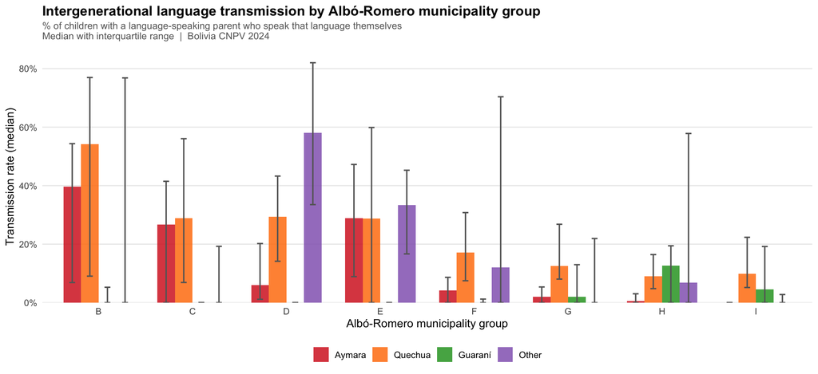

```r
albo_levels <- c("B","C","D","E","F","G","H","I")

lang_colors <- c(
  "Aymara"  = "#d62728",
  "Quechua" = "#ff7f0e",
  "Guaraní" = "#2ca02c",
  "Other"   = "#9467bd"
)

albo_compare <- bind_rows(
  aymara_by_albo  |> mutate(language = "Aymara"),
  quechua_by_albo |> mutate(language = "Quechua"),
  guarani_by_albo |> mutate(language = "Guaraní"),
  other_by_albo   |> mutate(language = "Other")
) |>
  filter(albo_group %in% albo_levels) |>
  mutate(
    albo_group = factor(albo_group, levels = albo_levels),
    language   = factor(language, levels = names(lang_colors))
  )

ggplot(albo_compare, aes(x = albo_group, y = transmission_median, fill = language)) +
  geom_col(position = "dodge", width = 0.75, alpha = 0.85) +
  geom_errorbar(
    aes(ymin = transmission_q25, ymax = transmission_q75),
    position = position_dodge(0.75),
    width = 0.25, linewidth = 0.7, color = "grey40"
  ) +
  scale_fill_manual(values = lang_colors) +
  scale_y_continuous(
    labels = scales::percent_format(),
    expand = expansion(mult = c(0, 0.05))
  ) +
  labs(
    title    = "Intergenerational language transmission by Albó-Romero municipality group",
    subtitle = "% of children with a language-speaking parent who speak that language themselves\nMedian with interquartile range  |  Bolivia CNPV 2024",
    x = "Albó-Romero municipality group",
    y = "Transmission rate (median)",
    fill = NULL
  ) +
  theme_minimal(base_size = 12) +
  theme(
    plot.title         = element_text(face = "bold", margin = margin(b = 4)),
    plot.subtitle      = element_text(color = "grey40", size = rel(0.85), margin = margin(b = 10)),
    panel.grid.major.x = element_blank(),
    panel.grid.minor.y = element_blank(),
    legend.position    = "bottom"
  )
```